# lab6

Андрей Мухтаров

20 декабря 2016 г

## R Markdown

Прочитайте файл в переменную

```r
data<-read.csv('https://raw.githubusercontent.com/SergeyMirvoda/da2016/master/lab6/wtid-report.csv')
```

На основе полученных данных создайте новую переменную в которой будут следующие колонки (наблюдения): ‘Year’, ‘P99’, ‘P99.5’ и ‘P99.9’;

```r
data2<-data.frame(Year=data$Year,P99=data$P99.income.threshold,P99.5=data$P99.5.income.threshold,P99.9=data$P99.9.income.threshold)
```

Чему равнялся P99 в 1972? P99.5 в 1942? P99.9 в 1922?

```r
data2$P99[data2$Year==1972]
```

```
## [1] 209076.6
```

```r
data2$P99.5[data2$Year==1942]
```

```
## [1] 183217
```

```r
data2$P99.9[data2$Year==1922]
```

```
## [1] 400214.2
```

Постройте диаграмму рассеяний всех трёх персентилей относительно времени. Проверьте, чтобы метки осей были корректными и на оси x были годы от 1913 до 2012.

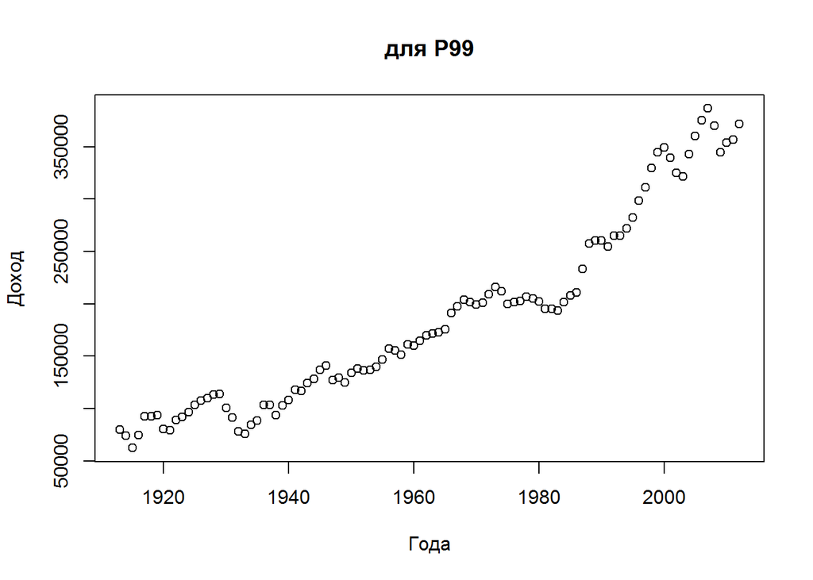

```r
plot(data2$Year,data2$P99,xlab = 'Года', ylab = 'Доход',main='для P99')
```

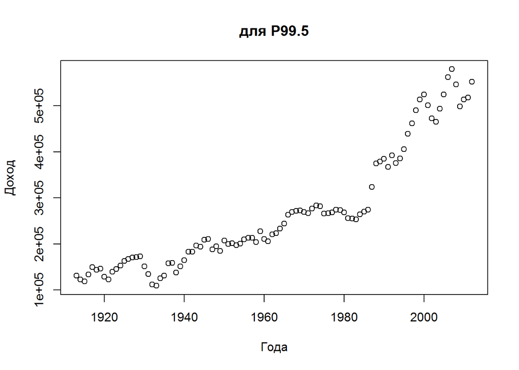

```r
plot(data2$Year,data2$P99.5,xlab = 'Года', ylab = 'Доход',main='для P99.5')
```

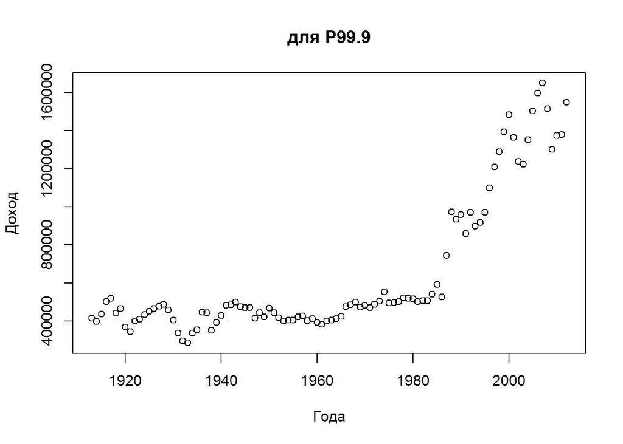

```r
plot(data2$Year,data2$P99.9,xlab = 'Года', ylab = 'Доход',main='для P99.9')
```

Из предыдущих вычислений можно получить, что оценить параметр a можно по следующей формуле: a = 1 - log(10)/log(P99/P99.9) (3). Напишите функцию my.exp.estimate_ratio, которая принимает аргументы P99 и P99.9 и возвращает a, рассчитанное по формуле (3). Проверьте, что при P99 = 1e6 и P99.9 = 1e7 функция вернёт a = 2. ###

```r
my.exp.estimate_ratio =function(x,y){
  a<-1-log(10)/log(x/y)
  return(a)
}

my.exp.estimate_ratio(10^6,10^7)
```

```
## [1] 2
```

Задание 2 Получите значение a для каждого года в наборе данных.

```r
a_year<-data.frame(year=data2$Year,a= my.exp.estimate_ratio(data2$P99,data2$P99.9))
```

Постройте график а относительно годов. Что можно сказать по полученному графику, соотносится ли это с тем, что имеется на самом деле? (Имейте ввиду, чем экспонента меньше, тем выше неравенство)

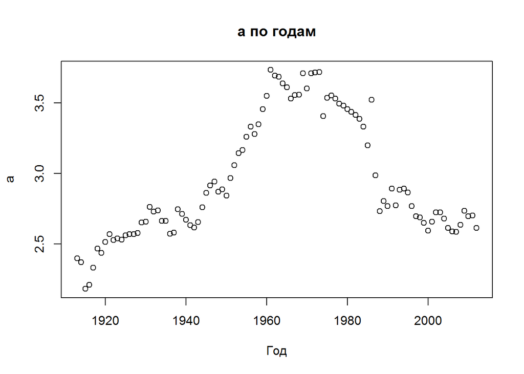

```r
plot(a_year,xlab='Год',ylab='a', main="a по годам")
```